# Executive summary

### Agriculture Sector — Disorderly transition — Details

The changes in food and bioenergy demand, emission pricing or taxes, consumer preferences and land use restrictions could potentially result in one or more of the following financial impacts:

- **Revenue growth** due to rising global demand and commodity prices.
- **Rising production costs** due to higher input costs and GHG emissions costs
- **Increase in capital expenditures** as farms need to invest in research and development and deployment of new technologies necessary for long-term productivity growth
- **More write-offs of assets** as expansion of land protection policies to preserve and expand forests could reduce land available for agriculture.

Agricultural producers can benefit from expanding markets but face greater risks of stranded assets, geographic growth constraints, and rising production costs in the face of new emissions costs, land use restrictions, and necessary productivity improvements.

The sector has very high GHG emissions as farm and livestock productions and activities are emission intensive. The total demand could continue to increase in the Disorderly transition risk scenarios, however growth in demand for food production is limited.

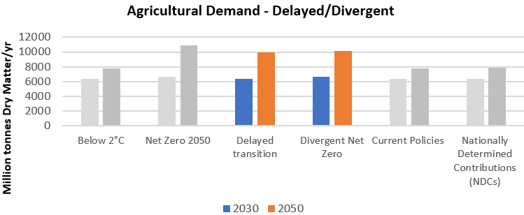

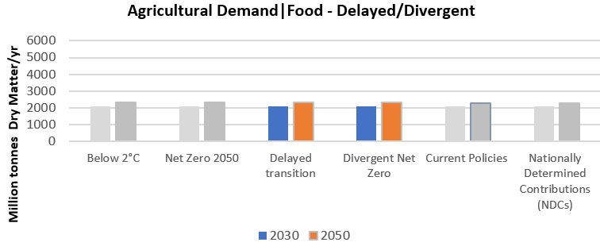

**Source:** [IIASA NGFS Climate Scenarios Database.](https://data.ece.iiasa.ac.at/ngfs/#/downloads)

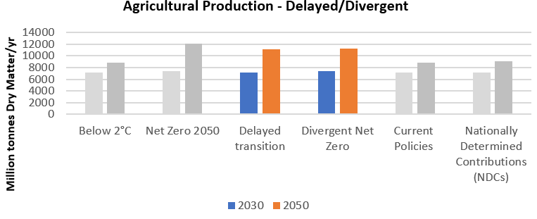

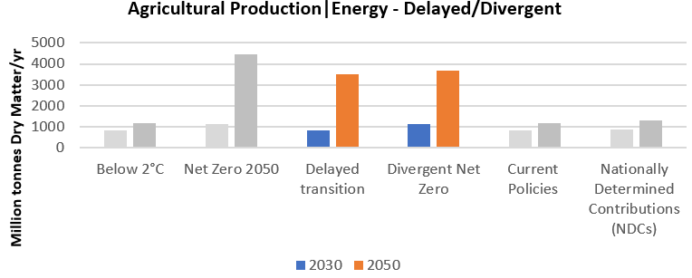

**Source:** [IIASA NGFS Climate Scenarios Database.](https://data.ece.iiasa.ac.at/ngfs/#/downloads)

Agricultural sector is key driver of forest loss, and due to forest conservation and preservation policies, availability of agricultural land reduces, limiting the growth of agricultural land cover. However, technological innovations in yields and productivity increase land use efficiency, allowing agriculture production to continue to increase with the rising demand of food and energy due to population growth. By 2050, agricultural land could increase by around 45 to 70 million hectares and forest cover could increase by around 160 million hectares.

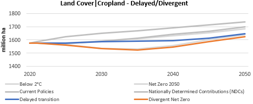

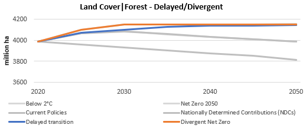

**Source:** [IIASA NGFS Climate Scenarios Database.](https://data.ece.iiasa.ac.at/ngfs/#/downloads)

The operational and production costs of firms could increase as they need to make necessary investments for technological upgrades and increase in carbon taxes. But producers should be able to pass the higher input costs to consumers due to inelastic demand of food and increasing usage of clean bioenergy and biofuels.

Despite these material risks, agricultural companies and investors can also derive significant opportunities from climate transitions. By investing in sustainable intensification, regenerative agriculture, and diversifying revenue streams, forward-looking agricultural companies could see their net value and profitability rise under transitions.

### Agriculture Sector — Low physical risk — Summary

The Agriculture sector is also exposed to physical risk. Chronic effects (e.g. raised sea-levels and mean temperatures) and acute effects due to changes to frequency and severity of weather events such as heatwaves, wildfires, tropical cyclones, and flooding are adding to pressures on global agricultural and food systems and could lead to severe disruption to agricultural production which could impact the profitability for some companies in long-run.

In the low physical risk scenario, climate change and global warming could increase weather variations. This could lead to increasing disruption to agriculture sector which could impact profitability.

### Agriculture Sector — Low physical risk — Details

The following examples illustrate how the agriculture sector could be impacted in a low physical risk scenario:

**Chronic Impacts**

- **Increase in sea-level rise and flooding**, may lead to substantial losses in crop and livestock production in low-lying agricultural areas and may contribute to waterlogging and soil erosion. Wetter weather could threaten agricultural production by adversely affecting crop yields.
- **Higher average temperatures** could have an impact on production, this could vary across the regions. Warmer, drier climate in already arid regions, such as North Africa, may have a negative impact on production, whereas production in colder and wetter areas, such as Northern and Western regions in the UK, may benefit from warm conditions.

**Acute Impacts**

- **Changing rainfall patterns**, reduced availability of water for irrigation could threaten agricultural production, particularly in areas where water supplies are already under pressure. Drier soil conditions could reduce growth of crops, pasture and trees. Extended or repeated period of droughts may cause death of younger tress reducing forest productivity.
- **Increased frequency and intensity of Wildfires, Cyclones or Storms** could cause significant damage to forests and disrupts the natural ecosystems that has been developed around the forests.

Physical risks could affect the range and quality of the ecosystem services that agriculture and forestry not only provide, but also rely on. These include climate control, flood regulation, biodiversity, pollination and nutrient cycling. The agriculture and forestry sectors have already adapted to change by introducing new genotypes, varieties, breeds and management practices. In a low physical risk scenario, there could be a need for more anticipatory adaptation measures.

# NGFS Hot House World Scenarios

These scenarios assume that some climate policies are implemented in some jurisdictions, but globally efforts are insufficient to halt significant global warming leading to high physical risk.

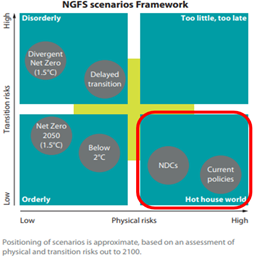

**Source:** [NGFS Climate Scenarios, June2021](https://www.ngfs.net/sites/default/files/media/2021/08/27/ngfs_climate_scenarios_phase2_june2021.pdf)

The NGFS have provided two hot house world scenarios:

- **Nationally Determined Contributions (NDCs)** includes all pledged policies even if not yet implemented.
- **Current Policies** assumes that only currently implemented policies are preserved, leading to high physical risk.

## Key physical assumptions and parameters

In these scenarios CO<sub>2</sub> emissions do not decrease sufficiently to prevent significant temperature rises resulting in high physical risk.

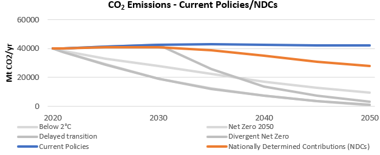

**Source:** [IIASA NGFS Scenario Explorer.](https://data.ece.iiasa.ac.at/ngfs/#/downloads)

Carbon price is a measure of overall policy intensity. Emission prices are sensitive to the timing of policy implementation. With none or relatively small additions to current policy, these scenarios have low carbon prices throughout. Therefore, transition risk is not relevant for these scenarios.

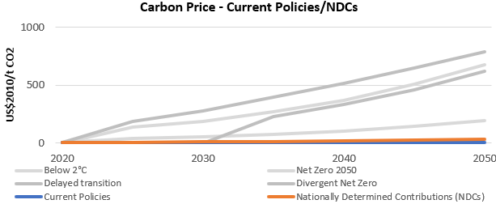

The investments in energy efficiency and low carbon technologies are projected to increase in Hot House scenarios. Annual investment in energy efficiency increases from around 200 billion USD (inflation adjusted to 2010 baseline) to between 250 billion USD and 350 billion USD by 2050, whilst annual investment in low carbon increases from ~750 billion USD to below ~2 trillion USD by 2050. However this increase is relatively small compared to other scenarios.

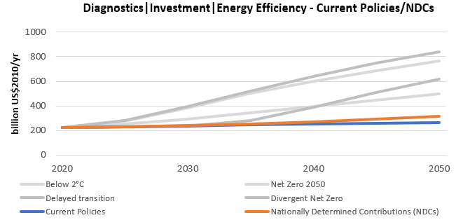

**Source:** [IIASA NGFS Scenario Explorer.](https://data.ece.iiasa.ac.at/ngfs/#/downloads)

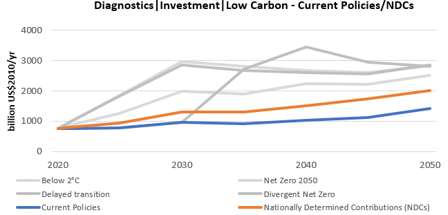

**Source:** [IIASA NGFS Scenario Explorer.](https://data.ece.iiasa.ac.at/ngfs/#/downloads)

The increasing concentrations of carbon dioxide, methane and nitrous oxide in the atmosphere are unprecedented in at least the last 800,000 years and are extremely likely to have been the dominant cause of warming since the mid-20th century. Observed climate change of 1.2°C, compared to pre-industrial levels, has already more than doubled both the global land area and the global population annually exposed to river flood, crop failure, tropical cyclones, wildfire, drought and heatwaves. In these scenarios global mean temperatures are projected to increase across the world by ~2°C, compared to pre-industrial levels, by 2050, with land warming faster than oceans and high latitudes experiencing higher warming.

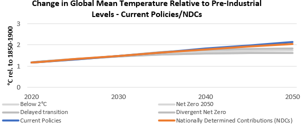

**Source:** [IIASA NGFS Scenario Explorer, NGFS Scenario Data IAM outputs v2.2 REMIND-MAgPIE 2.1-4.2 model](https://data.ece.iiasa.ac.at/ngfs/#/downloads)

These changes could lead to chronic changes in living conditions affecting health, labour productivity, agriculture, ecosystems, and sea-level rise. It can also change the frequency and severity of weather events such as heatwaves, droughts, wildfires, tropical cyclones, and flooding. For example, in the Current Policies scenario we could see the following:

- A decrease in labour productivity due to the reduced capacity of the human body to perform physical labour under hot and humid climate conditions.

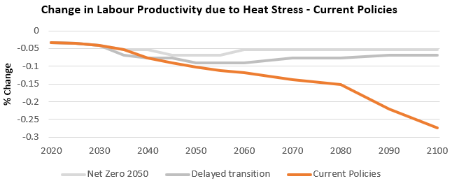

**Source:** [Climate Impact Explorer.](http://climate-impact-explorer.climateanalytics.org/)

- The annual economic damages from river floods are projected to increase, peaking at a ~200% increase over a 1986-2006 reference period around 2060. Annual economic damages from tropical cyclones are also projected to increase, but to a lesser extent; ~65% above reference period levels by the end of the century.

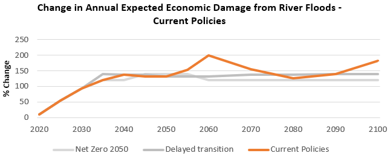

**Source:** [Climate Impact Explorer.](http://climate-impact-explorer.climateanalytics.org/)

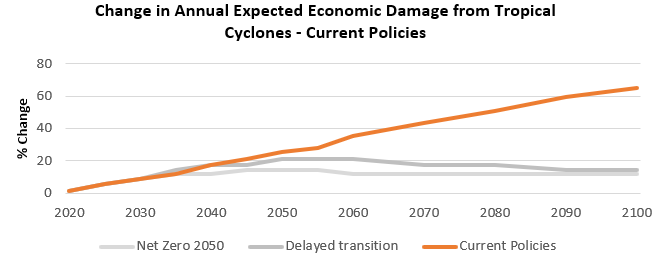

**Source:** [Climate Impact Explorer.](http://climate-impact-explorer.climateanalytics.org/)

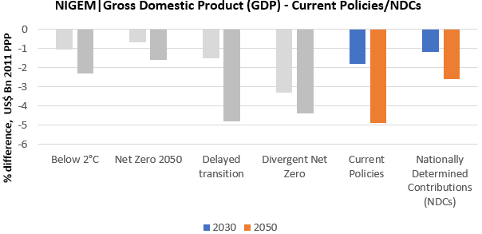

**Source:** [IIASA NGFS Scenario Explorer, NGFS Scenario Data NIGEM v2.0 NiGEM NGFS v1.21 model](https://data.ece.iiasa.ac.at/ngfs/#/downloads)

Overall, these scenarios result in high physical risk including irreversible impacts like sea-level rise. Transition risks are not relevant in these scenarios as only policies that are already implemented or pledged are in place.

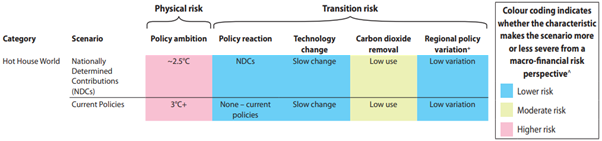

**Source:** [NGFS Climate Scenarios, June2021](https://www.ngfs.net/sites/default/files/media/2021/08/27/ngfs_climate_scenarios_phase2_june2021.pdf)

## Agriculture Sector

The **Agriculture** sector can be split into crop production and animal production.

Industries in the Crop Production subsector grow crops mainly for food and fibre. This subsector comprises establishments such as farms, orchards, groves, greenhouses, and nurseries, primarily engaged in growing crops, plants, vines, or trees and their seeds. The industries in this subsector are grouped by similarity of production activity, the length of growing season, degree of crop rotation, extent of input specialization, labour requirements and capital demands.

The production process is typically completed when the raw product or commodity grown reaches the “farm gate” for market, that is, at the point of first sale or price determination. Within the subsector, the NAICS classifies establishments to a specific industry when a product or industry family of products (i.e., oilseed and grain farming, vegetable and melon farming, fruit and tree nut farming) account for one-half or more of the establishment’s agricultural production.

Industries in the Animal Production and Aquaculture subsector raise or fatten animals for the sale of animals or animal products and/or raise aquatic plants and animals in controlled or selected aquatic environments for the sale of aquatic plants, animals, or their products. The subsector includes establishments, such as ranches, farms, and feedlots primarily engaged in keeping, grazing, breeding, or feeding animals. These animals are kept for the products they produce or for eventual sale. The industries in this subsector are grouped by important factors, such as suitable grazing or pastureland, specialized buildings, type of equipment and the amount and types of labour required.

The Agriculture sector is also exposed to physical risk. Chronic effects (e.g. raised sea-levels and mean temperatures) and acute effects due to changes to frequency and severity of weather events such as heatwaves, wildfires, tropical cyclones, and flooding are adding to pressures on global agricultural and food systems and could lead to severe disruption to agricultural production which could impact the profitability for some companies in long-run. Whilst the agriculture sector is used to responding to and managing changing weather conditions, in the high physical risk scenario, climate change and global warming could increase weather variations. This could lead to increasing disruption to agriculture sector which could impact profitability.

Adverse impacts on world GDP from physical risks are assumed in the scenarios and these scale with the rise in temperatures in the scenarios over time. The high physical risk scenarios could therefore also lead to a significant GDP impact which could negatively impact demand for agriculture, although the impact is likely to be limited due to inelastic demand for food products.

### Agriculture Sector — High physical risk — Details

The following examples illustrate how the Agriculture sector could be impacted in a high physical risk scenario:

**Chronic Impacts**

- **Increase in sea-level rise**, may lead to substantial losses in crop and livestock production in low-lying agricultural areas and may contribute to waterlogging and soil erosion. Wetter weather could threaten agricultural production by adversely affecting crop yields.
- **Higher average temperatures** could have an impact on production, this could vary across the regions. Warmer, drier climates in tropical regions may have a negative impact on production where production in colder and wetter areas may benefit from warm conditions.

**Acute Impacts**

- **Changing rainfall patterns**, reduced availability of water for irrigation could threaten agricultural production, particularly in areas where water supplies are already under pressure. Drier soil conditions could reduce growth of crops, pasture and trees. Extended or repeated period of droughts may cause death of younger tress reducing forest productivity.
- **Increased frequency and intensity of Wildfires, Cyclones or Storms** could cause significant damage to forests and disrupts the natural ecosystems that has been developed around the forests.

Significantly slowed GDP growth could impact demand for agriculture through its effect on individuals’ disposable income. The impact on food products is likely to be low due to inelastic demand, but demand for bioenergy could see growth partially offset.

Physical risks could affect the range and quality of the ecosystem services that agriculture and forestry not only provide, but also rely on. These include climate control, flood regulation, biodiversity, pollination and nutrient cycling. The agriculture and forestry sectors have already adapted to change by introducing new genotypes, varieties, breeds and management practices. In a high physical risk scenario, there could be a need for more anticipatory adaptation measures.

# References

## Agriculture Sector

- [How will African farmers adjust to changing patterns of precipitation? - McKinsey, May 2020](https://www.mckinsey.com/business-functions/sustainability/our-insights/how-will-african-farmers-adjust-to-changing-patterns-of-precipitation)
- [Agriculture and Forestry Climate Change Impacts - Living With Environmental Change, Report Card 2016](https://nerc.ukri.org/research/partnerships/ride/lwec/report-cards/agriculture/)
- [NAICS Code 11](https://www.naics.com/six-digit-naics/?code=11)
- [SIC Code A](https://www.naics.com/sic-codes-counts-division/?div=A)